# 24-01_DataStruct_01a

## Data structures and Algorithms

### 1.2 Stack

```python
from DataStructures import Stack

# 1.2 Create stack, test methods

sklad = Stack('TestStack')

sklad.push('A')
sklad.push('B')
sklad.push('C')
sklad.print()


print("Pop() returned: ", sklad.pop() )
sklad.print()

print("Pop() returned: ", sklad.pop() )
sklad.print()

print("Pop() returned: ", sklad.pop() )
sklad.print()

print("Pop() returned: ", sklad.pop() )
sklad.print()
```

```
TestStack size: 3 , data: ['A', 'B', 'C']
Pop() returned:  C
TestStack size: 2 , data: ['A', 'B']
Pop() returned:  B
TestStack size: 1 , data: ['A']
Pop() returned:  A
TestStack size: 0 , data: []
Pop() returned:  None
TestStack size: 0 , data: []
```

```python
from DataStructures import Stack, Queue

# 1.3 Create queue, test methods

q = Queue()

q.push('A')
q.push('B')
q.push('C')
q.enqueue('D')
q.print()


print("Pop() returned: ", q.pop() )
q.print()

print("Pop() returned: ", q.pop() )
q.print()

print("Pop() returned: ", q.pop() )
q.print()

print("Pop() returned: ", q.dequeue() )
q.print()
```

```
MyQueue size: 4 , data: ['A', 'B', 'C', 'D']
Pop() returned:  A
MyQueue size: 3 , data: ['B', 'C', 'D']
Pop() returned:  B
MyQueue size: 2 , data: ['C', 'D']
Pop() returned:  C
MyQueue size: 1 , data: ['D']
Pop() returned:  D
MyQueue size: 0 , data: []
```

```python
text = 'Danes je lep sončen dan.'
output = ''

s = Stack()

for ch in text:
    s.push(ch)
#s.print()

while not s.empty():
    output += s.pop()


#ch = s.pop()
#while ch != None:
#    output += ch
#    ch = s.pop()

print(output)
```

[output not shown]

```python
text = 'Danes je lep sončen dan in občudujem mavrico na nebu.'
output = ''

q = Queue('Samoglasniki')

for ch in text:
    if ch not in ['a','e','i','o','u']:
        q.enqueue(ch)
q.print()

while not q.empty():
    output += q.dequeue()

print(output)

q.print()
```

```
Samoglasniki size: 35 , data: ['D', 'n', 's', ' ', 'j', ' ', 'l', 'p', ' ', 's', 'n', 'č', 'n', ' ', 'd', 'n', ' ', 'n', ' ', 'b', 'č', 'd', 'j', 'm', ' ', 'm', 'v', 'r', 'c', ' ', 'n', ' ', 'n', 'b', '.']
Dns j lp snčn dn n bčdjm mvrc n nb.
Samoglasniki size: 0 , data: []
```

## 2. Algoritmi / Algorithms

Algoritmi so po definiciji navodilo, s katerim rešujemo problem, podano kot seznam korakov, ki nas pripeljejo do rešitve problema. V praksi to hkrati pomeni, da lahko za vsak algoritem obstaja poljubno mnogo rešitev (programov), ki ta algoritem izvajajo. Kompleksnejši algoritmi tako ponavadi tudi zahtevajo kompleksnejše tipe podatkov oziroma podatkovnih struktur, s pomočjo katerih lahko sledimo (vmesnim) rezultatom ter prikazujemo napredek postopka. Algoritme pogosto prikažemo tudi z grafom poteka korakov. Pravilna izbira podatkovne strukture ima tako velik vpliv na pravilno interpretacijo rezultatov. V sklopu laboratorijske vaje si bomo tako pogledali dva algoritma.

> By definition algorithms are a set of rules / instructions used to solve a set problem. These instructions are a series of steps which lead us to the solution of the problem. This means that we can implement each algorithm in many different ways, depending on the environment constraints (RAM, CPU speed etc.). Complex algorithms usually require complex data structures which enable us to monitor and report the progress. Algorithms can also be presented graphically. The choice of data structures plays an important part in the interpretation of results.

> We will present two algorithm implemenations - a simple number base converter and a more complex traffic buffer simulator.

## 2.1 Pretvorba števil / Number base conversion

> The following two function convert a decimal number to binary and back. Note that we used the stack data structure as it retains the bit order i.e. the first bit returned by it's pop is the most important (highest power) one.

```python
# Conversion to binary
def decToBinary( x ):
    out = Stack('Bits')

    while x > 0:
        bit = x % 2
        out.push(bit)
        x = x // 2
    return out


bin = decToBinary(253)
bin.print()
print(bin.get_data()[::-1])
```

```
Bits size: 8 , data: [1, 0, 1, 1, 1, 1, 1, 1]
[1, 1, 1, 1, 1, 1, 0, 1]
```

```python
# Conversion to binary
def decToBinary2( x ):
    out = Queue('Bits')

    while x > 0:
        bit = x % 2
        out.push(bit)
        x = x // 2
    return out


bin = decToBinary2(253)
bin.print()
print(bin.get_data()[::-1])
```

```
Bits size: 8 , data: [1, 0, 1, 1, 1, 1, 1, 1]
[1, 1, 1, 1, 1, 1, 0, 1]
```

```python
from DataStructures import Stack, Queue

# binary to decimal
def binaryToDecimal( st ):
    out = 0
    potenca = 2**(st.size()-1)
    while not st.empty():
        out += potenca*st.pop()
        potenca = potenca // 2

    return out

bin = decToBinary(122342312)
bin.print()
print(bin.get_data()[::-1])

print(binaryToDecimal(bin))
```

```
Bits size: 27 , data: [0, 0, 0, 1, 0, 1, 0, 1, 1, 1, 0, 1, 0, 0, 1, 1, 0, 1, 0, 1, 0, 0, 1, 0, 1, 1, 1]
[1, 1, 1, 0, 1, 0, 0, 1, 0, 1, 0, 1, 1, 0, 0, 1, 0, 1, 1, 1, 0, 1, 0, 1, 0, 0, 0]
122342312
```

```python
from DataStructures import Stack, Queue

# binary to decimal
def binaryToDecimal2( st ):
    out = 0
    potenca = 1 #2**(st.size()-1)
    while not st.empty():
        out += potenca*st.dequeue()
        potenca = potenca * 2

    return out

bin = decToBinary2(122342312)
bin.print()
print(bin.get_data()[::-1])

print(binaryToDecimal2(bin))
```

```
Bits size: 27 , data: [0, 0, 0, 1, 0, 1, 0, 1, 1, 1, 0, 1, 0, 0, 1, 1, 0, 1, 0, 1, 0, 0, 1, 0, 1, 1, 1]
[1, 1, 1, 0, 1, 0, 0, 1, 0, 1, 0, 1, 1, 0, 0, 1, 0, 1, 1, 1, 0, 1, 0, 1, 0, 0, 0]
122342312
```

### Kreiraj graf

```
Graph nodes:  ['Ljubljana', 'Celje', 'Maribor', 'Ptuj', 'Murska Sobota', 'Krsko', 'Novo mesto', 'Kocevje', 'Postojna', 'Koper', 'Kranj', 'Jesenice', 'Nova Gorica', 'Velenje', 'Dravograd']
{'Ljubljana': [0, 0], 'Celje': [6, 2], 'Maribor': [9, 5], 'Ptuj': [10, 4], 'Murska Sobota': [12, 7], 'Krsko': [7, -1], 'Novo mesto': [5, -3], 'Kocevje': [2, -5], 'Postojna': [-3, -2], 'Koper': [-6, -6], 'Kranj': [-1, 2], 'Jesenice': [-4, 4], 'Nova Gorica': [-7, -1], 'Velenje': [5, 4], 'Dravograd': […
[('Ljubljana', 'Kranj'), ('Ljubljana', 'Novo mesto'), ('Ljubljana', 'Celje'), ('Ljubljana', 'Postojna'), ('Ljubljana', 'Kocevje'), ('Celje', 'Maribor'), ('Celje', 'Velenje'), ('Maribor', 'Murska Sobota'), ('Maribor', 'Ptuj'), ('Krsko', 'Novo mesto'), ('Postojna', 'Nova Gorica'), ('Postojna', 'Koper'…
26
72
73
51
60
39
63
64
37
54
23
60
26
36
{('Ljubljana', 'Kranj'): 26, ('Ljubljana', 'Novo mesto'): 72, ('Ljubljana', 'Celje'): 73, ('Ljubljana', 'Postojna'): 51, ('Ljubljana', 'Kocevje'): 60, ('Kranj', 'Jesenice'): 39, ('Nova Gorica', 'Postojna'): 63, ('Postojna', 'Koper'): 64, ('Novo mesto', 'Krsko'): 37, ('Celje', 'Maribor'): 54, ('Celje…
```

[output not shown]

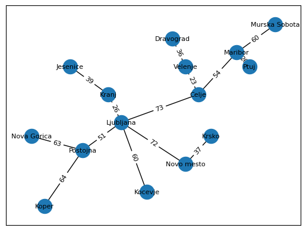

```python
import matplotlib.pyplot as plt
import networkx as nx
import warnings
warnings.filterwarnings('ignore')
%matplotlib inline

# prepare an empty figure
plt.figure()

Gr = nx.Graph()

nodes = [
    ("Ljubljana", {"x":0, "y": 0}),
    ("Celje", {"x":6, "y": 2}),
    ("Maribor", {"x":9, "y": 5}),
    ("Ptuj", {"x":10, "y": 4}),
    ("Murska Sobota", {"x":12, "y": 7}),
    ("Krsko", {"x":7, "y": -1}),
    ("Novo mesto", {"x":5, "y": -3}),
    ("Kocevje", {"x":2, "y": -5}),
    ("Postojna", {"x":-3, "y": -2}),
    ("Koper", {"x":-6, "y": -6}),
    ("Kranj", {"x":-1, "y": 2}),
    ("Jesenice", {"x":-4, "y": 4}),
    ("Nova Gorica", {"x":-7, "y": -1}),
    ("Velenje", {"x":5, "y": 4}),
    ("Dravograd", {"x":4, "y": 6}),
]
Gr.add_nodes_from(nodes)

Gr.nodes["Ljubljana"]

print("Graph nodes: ",  Gr.nodes)

# Pridobi pozicije iz podatkov
position = {}
for i in Gr.nodes:
    position[i] = [Gr.nodes[i]['x'], Gr.nodes[i]['y']]
print(position)


# Add edges with weights (distance)
#Gr.add_edge("Ljubljana","Kranj")
edge_list = [
    ("Ljubljana","Kranj", {"km":26}),
    ("Ljubljana","Novo mesto", {"km":72}),
    ("Ljubljana","Celje", {"km":73}),
    ("Ljubljana","Postojna", {"km":51}),
    ("Ljubljana","Kocevje", {"km":60}),
    ("Kranj","Jesenice", {"km":39}),
    #("Nova Gorica","Jesenice", {"km":178}),
    ("Nova Gorica","Postojna", {"km":63}),
    #("Nova Gorica","Koper", {"km":101}),
    ("Postojna","Koper", {"km":64}),
    #("Novo mesto","Kocevje", {"km":49}),
    ("Novo mesto","Krsko", {"km":37}),
    #("Celje","Krsko", {"km":58}),
    ("Celje","Maribor", {"km":54}),
    ("Celje","Velenje", {"km":23}),
    ("Maribor","Murska Sobota", {"km":60}),
    ("Maribor","Ptuj", {"km":26}),
    ("Dravograd","Velenje", {"km":36}),
    #("Dravograd","Maribor", {"km":61})
]

Gr.add_edges_from(edge_list)

print(Gr.edges)

edge_labels = {}
for e in edge_list:
    print(e[2]["km"])
    #edge_labels.append(e[2]["km"])
    edge_labels[(e[0],e[1])] = e[2]["km"]

print(edge_labels )

#Plot the graph
#nx.draw_networkx(Gr, position, with_labels=True)


#Plot the graph
nx.draw_networkx(Gr, position, with_labels=True, font_size = 8)
nx.draw_networkx_edge_labels(Gr, position, edge_labels=edge_labels, font_size = 8)


# Save graph
# nx.write_graphml(Gr,'Slo_cities_tree.graphml')
```

### 2.3 Sprehod v globino DFS

```
['Ljubljana', 'Celje', 'Maribor', 'Ptuj', 'Murska Sobota', 'Krsko', 'Novo mesto', 'Kocevje', 'Postojna', 'Koper', 'Kranj', 'Jesenice', 'Nova Gorica', 'Velenje', 'Dravograd']
[('Ljubljana', 'Kranj'), ('Ljubljana', 'Novo mesto'), ('Ljubljana', 'Celje'), ('Ljubljana', 'Postojna'), ('Ljubljana', 'Kocevje'), ('Celje', 'Maribor'), ('Celje', 'Velenje'), ('Maribor', 'Murska Sobota'), ('Maribor', 'Ptuj'), ('Krsko', 'Novo mesto'), ('Postojna', 'Nova Gorica'), ('Postojna', 'Koper'…
```

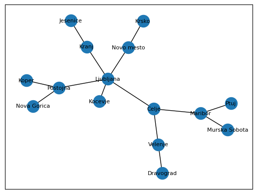

```python
import matplotlib.pyplot as plt
import networkx as nx

# Load graph
G = nx.read_graphml('Slo_cities_tree.graphml')
print(G.nodes)
print(G.edges)

# prepare an empty figure
plt.figure()

#Plot the graph
nx.draw_networkx(G, with_labels=True, font_size = 8)
```

```python
# DFS Algorithm
from DataStructures import Stack

# Select your input graph (networkx Graph):
inputGr = G
print("Input Graph nodes:", inputGr.nodes)

# Select your starting point:
start_node = 'Ljubljana'

# Perform node visit
def visit_node(node, visited, visited_order, stack, graph, counter_list):
    visited.add(node)
    visited_order.append((counter_list[0], node))
    print("Visit: ", counter_list[0], node)
    counter_list[0]+=1
    for sosed in graph.adj[node]:
        if sosed not in visited:
            stack.push(sosed)
    # preglej kaj je na skladu
    stack.print()

# Create a set to store visited vertices
visited = set()
# Create stack to store nodes to visit
stack = Stack()
# iterator over visits
counter_list = [0]
# Resulting sequence
node_order = []

# ALGORITHM DFS
node = start_node
visit_node(node, visited, node_order, stack, inputGr, counter_list)
while stack.size() > 0:
    node = stack.pop()
    if node not in visited:
        visit_node(node, visited, node_order, stack, inputGr, counter_list)

print("Visited nodes: ", node_order)
```

```
Input Graph nodes: ['Ljubljana', 'Celje', 'Maribor', 'Ptuj', 'Murska Sobota', 'Krsko', 'Novo mesto', 'Kocevje', 'Postojna', 'Koper', 'Kranj', 'Jesenice', 'Nova Gorica', 'Velenje', 'Dravograd']
Visit:  0 Ljubljana
MyStack size: 5 , data: ['Kranj', 'Novo mesto', 'Celje', 'Postojna', 'Kocevje']
Visit:  1 Kocevje
MyStack size: 4 , data: ['Kranj', 'Novo mesto', 'Celje', 'Postojna']
Visit:  2 Postojna
MyStack size: 5 , data: ['Kranj', 'Novo mesto', 'Celje', 'Nova Gorica', 'Koper']
Visit:  3 Koper
MyStack size: 4 , data: ['Kranj', 'Novo mesto', 'Celje', 'Nova Gorica']
Visit:  4 Nova Gorica
MyStack size: 3 , data: ['Kranj', 'Novo mesto', 'Celje']
Visit:  5 Celje
MyStack size: 4 , data: ['Kranj', 'Novo mesto', 'Maribor', 'Velenje']
Visit:  6 Velenje
MyStack size: 4 , data: ['Kranj', 'Novo mesto', 'Maribor', 'Dravograd']
Visit:  7 Dravograd
MyStack size: 3 , data: ['Kranj', 'Novo mesto', 'Maribor']
Visit:  8 Maribor
MyStack size: 4 , data: ['Kranj', 'Novo mesto', 'Murska Sobota', 'Ptuj']
Visit:  9 Ptuj
MyStack size: 3 , data: ['Kranj', 'Novo mesto', 'Murska Sobota']
Visit:  10 Murska Sobota
MyStack size: 2 , data: ['Kranj', 'Novo mesto']
Visit:  11 Novo mesto
MyStack size: 2 , data: ['Kranj', 'Krsko']
Visit:  12 Krsko
MyStack size: 1 , data: ['Kranj']
Visit:  13 Kranj
MyStack size: 1 , data: ['Jesenice']
Visit:  14 Jesenice
MyStack size: 0 , data: []
Visited nodes:  [(0, 'Ljubljana'), (1, 'Kocevje'), (2, 'Postojna'), (3, 'Koper'), (4, 'Nova Gorica'), (5, 'Celje'), (6, 'Velenje'), (7, 'Dravograd'), (8, 'Maribor'), (9, 'Ptuj'), (10, 'Murska Sobota'), (11, 'Novo mesto'), (12, 'Krsko'), (13, 'Kranj'), (14, 'Jesenice')]
```

```python
## BFS Algorithm

from DataStructures import Stack, Queue

def visit_node(node, visited, visited_order, queue, graph, counter_list):
    visited.add(node)
    visited_order.append((counter_list[0], node))
    print("Visit: ", counter_list[0], node)
    counter_list[0]+=1
    for sosed in graph.adj[node]:
        if sosed not in visited:
            #if stack.indexOf(sosed) == None:
            queue.enqueue(sosed)
    # preglej kaj je v vrsti
    queue.print()


# Create a set to store visited vertices
visited = set()
# Store nodes to be visited in the queue
queue = Queue()
# counter : the number of visits
counter_list = [0]

# Resulting sequence
node_order = []


start_node = 'Murska Sobota'


print("Graph nodes:", Gr.nodes)

# ALGORITHM DFS
node = start_node
visit_node(node, visited, node_order, queue, Gr, counter_list)
while queue.size() > 0:
    node = queue.dequeue()
    if node not in visited:
        visit_node(node, visited, node_order, queue, Gr, counter_list)


print("Visited nodes: ", node_order)
```

```
Graph nodes: ['Ljubljana', 'Celje', 'Maribor', 'Ptuj', 'Murska Sobota', 'Krsko', 'Novo mesto', 'Kocevje', 'Postojna', 'Koper', 'Kranj', 'Jesenice', 'Nova Gorica', 'Velenje', 'Dravograd']
Visit:  0 Murska Sobota
MyQueue size: 1 , data: ['Maribor']
Visit:  1 Maribor
MyQueue size: 2 , data: ['Celje', 'Ptuj']
Visit:  2 Celje
MyQueue size: 3 , data: ['Ptuj', 'Ljubljana', 'Velenje']
Visit:  3 Ptuj
MyQueue size: 2 , data: ['Ljubljana', 'Velenje']
Visit:  4 Ljubljana
MyQueue size: 5 , data: ['Velenje', 'Kranj', 'Novo mesto', 'Postojna', 'Kocevje']
Visit:  5 Velenje
MyQueue size: 5 , data: ['Kranj', 'Novo mesto', 'Postojna', 'Kocevje', 'Dravograd']
Visit:  6 Kranj
MyQueue size: 5 , data: ['Novo mesto', 'Postojna', 'Kocevje', 'Dravograd', 'Jesenice']
Visit:  7 Novo mesto
MyQueue size: 5 , data: ['Postojna', 'Kocevje', 'Dravograd', 'Jesenice', 'Krsko']
Visit:  8 Postojna
MyQueue size: 6 , data: ['Kocevje', 'Dravograd', 'Jesenice', 'Krsko', 'Nova Gorica', 'Koper']
Visit:  9 Kocevje
MyQueue size: 5 , data: ['Dravograd', 'Jesenice', 'Krsko', 'Nova Gorica', 'Koper']
Visit:  10 Dravograd
MyQueue size: 4 , data: ['Jesenice', 'Krsko', 'Nova Gorica', 'Koper']
Visit:  11 Jesenice
MyQueue size: 3 , data: ['Krsko', 'Nova Gorica', 'Koper']
Visit:  12 Krsko
MyQueue size: 2 , data: ['Nova Gorica', 'Koper']
Visit:  13 Nova Gorica
MyQueue size: 1 , data: ['Koper']
Visit:  14 Koper
MyQueue size: 0 , data: []
Visited nodes:  [(0, 'Murska Sobota'), (1, 'Maribor'), (2, 'Celje'), (3, 'Ptuj'), (4, 'Ljubljana'), (5, 'Velenje'), (6, 'Kranj'), (7, 'Novo mesto'), (8, 'Postojna'), (9, 'Kocevje'), (10, 'Dravograd'), (11, 'Jesenice'), (12, 'Krsko'), (13, 'Nova Gorica'), (14, 'Koper')]
```

```python
## BFS Algorithm : Minimum number of edges to each node

from DataStructures import Queue

def visit_node(node, node_level, visited, visited_order, queue, graph, counter_list):
    visited.add(node)
    visited_order.append([node, node_level])
    node_level += 1

    #print("Visit: ", counter_list[0], node)
    counter_list[0]+=1
    for sosed in graph.adj[node]:
        if sosed not in visited:
            #if stack.indexOf(sosed) == None:
            queue.enqueue([sosed,node_level])
    # preglej kaj je v vrsti
    queue.print()


# Create a set to store visited vertices
visited = set()
# Store nodes to be visited in the queue
queue = Queue()
# counter : the number of visits
counter_list = [0]

# Resulting sequence
node_order = []

start_node = 'Ljubljana'

print("Graph nodes:", Gr.nodes)

# ALGORITHM BFS
node = start_node
visit_node(node, 0, visited, node_order, queue, Gr, counter_list)
while queue.size() > 0:
    [node, level] = queue.dequeue()
    if node not in visited:
        visit_node(node, level, visited, node_order, queue, Gr, counter_list)


print("Visited nodes: ", node_order)
```

```
Graph nodes: ['Ljubljana', 'Celje', 'Maribor', 'Ptuj', 'Murska Sobota', 'Krsko', 'Novo mesto', 'Kocevje', 'Postojna', 'Koper', 'Kranj', 'Jesenice', 'Nova Gorica', 'Velenje', 'Dravograd']
MyQueue size: 5 , data: [['Kranj', 1], ['Novo mesto', 1], ['Celje', 1], ['Postojna', 1], ['Kocevje', 1]]
MyQueue size: 5 , data: [['Novo mesto', 1], ['Celje', 1], ['Postojna', 1], ['Kocevje', 1], ['Jesenice', 2]]
MyQueue size: 5 , data: [['Celje', 1], ['Postojna', 1], ['Kocevje', 1], ['Jesenice', 2], ['Krsko', 2]]
MyQueue size: 6 , data: [['Postojna', 1], ['Kocevje', 1], ['Jesenice', 2], ['Krsko', 2], ['Maribor', 2], ['Velenje', 2]]
MyQueue size: 7 , data: [['Kocevje', 1], ['Jesenice', 2], ['Krsko', 2], ['Maribor', 2], ['Velenje', 2], ['Nova Gorica', 2], ['Koper', 2]]
MyQueue size: 6 , data: [['Jesenice', 2], ['Krsko', 2], ['Maribor', 2], ['Velenje', 2], ['Nova Gorica', 2], ['Koper', 2]]
MyQueue size: 5 , data: [['Krsko', 2], ['Maribor', 2], ['Velenje', 2], ['Nova Gorica', 2], ['Koper', 2]]
MyQueue size: 4 , data: [['Maribor', 2], ['Velenje', 2], ['Nova Gorica', 2], ['Koper', 2]]
MyQueue size: 5 , data: [['Velenje', 2], ['Nova Gorica', 2], ['Koper', 2], ['Murska Sobota', 3], ['Ptuj', 3]]
MyQueue size: 5 , data: [['Nova Gorica', 2], ['Koper', 2], ['Murska Sobota', 3], ['Ptuj', 3], ['Dravograd', 3]]
MyQueue size: 4 , data: [['Koper', 2], ['Murska Sobota', 3], ['Ptuj', 3], ['Dravograd', 3]]
MyQueue size: 3 , data: [['Murska Sobota', 3], ['Ptuj', 3], ['Dravograd', 3]]
MyQueue size: 2 , data: [['Ptuj', 3], ['Dravograd', 3]]
MyQueue size: 1 , data: [['Dravograd', 3]]
MyQueue size: 0 , data: []
Visited nodes:  [['Ljubljana', 0], ['Kranj', 1], ['Novo mesto', 1], ['Celje', 1], ['Postojna', 1], ['Kocevje', 1], ['Jesenice', 2], ['Krsko', 2], ['Maribor', 2], ['Velenje', 2], ['Nova Gorica', 2], ['Koper', 2], ['Murska Sobota', 3], ['Ptuj', 3], ['Dravograd', 3]]
```

```python
print (list(nx.dfs_edges(Gr,start_node)))
```

```
[('Ljubljana', 'Kranj'), ('Kranj', 'Jesenice'), ('Ljubljana', 'Novo mesto'), ('Novo mesto', 'Krsko'), ('Ljubljana', 'Celje'), ('Celje', 'Maribor'), ('Maribor', 'Murska Sobota'), ('Maribor', 'Ptuj'), ('Celje', 'Velenje'), ('Velenje', 'Dravograd'), ('Ljubljana', 'Postojna'), ('Postojna', 'Nova Gorica'…
```

```
Total time:  3316
[1, 0, 0, 1, 1, 2, 2, 2, 3, 4, 4, 3, 3, 3, 3, 4, 5, 6, 6, 7, 7, 8, 9, 9, 9, 10, 11, 11, 12, 13, 13, 13, 13, 14, 14, 15, 15, 14, 14, 14, 14, 15, 15, 16, 17, 17, 17, 18, 18, 19, 20, 20, 20, 20, 20, 20, 20, 20, 21, 21, 21, 21, 21, 22, 22, 21, 20, 21, 22, 22, 21, 21, 22, 23, 24, 24, 23, 22, 23, 23, 23, …
[1, 2, 3, 4, 5, 6, 7, 8, 9, 10, 11, 12, 13, 14, 15, 16, 17, 18, 19, 20, 21, 22, 23, 24, 25, 26, 27, 28, 29, 30, 31, 32, 33, 34, 35, 36, 37, 38, 39, 40, 41, 42, 43, 44, 45, 46, 47, 48, 49, 50, 51, 52, 53, 54, 55, 56, 57, 58, 59, 60, 61, 62, 63, 64, 65, 66, 67, 68, 69, 70, 71, 72, 73, 74, 75, 76, 77, …
```

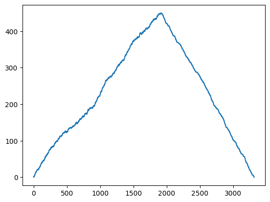

```python
import numpy as np

# SIMULATION PARAMETERS
input_data_size = 1000
add_probability = 0.5
remove_probability = 0.3


time = 0
input_number = 1

# Outputs
buff_size = []
time_list = []
out_list = []

buffer = Queue('Buffer')

while not (input_number > input_data_size and buffer.empty()):

    time_list.append(time)
    time += 1

    # add input data to queue
    if np.absolute(np.random.random()) < add_probability and input_number <= input_data_size :
        buffer.enqueue(input_number)
        input_number += 1

    # remove data
    if np.absolute(np.random.random()) < remove_probability:
        out = buffer.dequeue()
        if out != None:
            out_list.append(out)

    buff_size.append(buffer.size())

print('Total time: ', time)
print(buff_size)
print(out_list)

plt.figure()
plt.plot(buff_size)
plt.show()
```